# Takehome Test 2

Gary Fowler

November 8, 2017

## Problem 1

Give precise definitions/descriptions for each of the following terms.

(A)a statistic - is a collection of data used to explain or understand a piece of information. This data is generally used to make inferences about unknowns. (B)the maximum likelihood estimator(MLE) - the value of an estimate($\theta$) maximizing $f(x_1,...,x_n|\theta$ where x are the observed values. (Ca)sample mean - $\bar X = \Sigma_{i=1}^{n} X_i/n$ the sample mean is a collection of data and the average across that collection.The central limit theorem can be used to approximate the distribution of this mean which is normal. (Cb)sample variance - $S^2 = \frac{\Sigma_{i=1}^{n} (X_i - \bar X)^2}{n-1}$ (D)the Central Limit Theorem - Let $X_1,X_2,...,X_n$ be a sequence of independent identically distributed random variables each with mean $\mu$ and variance $\sigma^2$. For a large n, the distribution is approximately normal with mean $n\mu$ and variance $n\sigma^2$. Thus for n large $P(\frac{X_1,X_2,...,X_n-n\mu}{\sigma \sqrt{n}}<x) = P(Z < x)$ (E)the Z score for the standard normal distribution N(0,1) - This means mu is 0 and standard deviation is 1 leading to the 68-95-99 principal. 68% of the sample lie within 1 standard deviation, 95% within 2 and 99% within 3. (F) covariance and correlation of (X,Y) - $Cov(X,Y) = E[(x-\mu_x)(y-\mu_y)] = E[XY] - E[X]E[Y]$ $Corr(X,Y) = \frac{Cov(X,Y)}{\sigma_x\sigma_y}$

## Problem 2

A surveyor is measuring the height of a cliff known to be about 1000ft. He assumes his instrument is properly calibrated and that his measurement errors are independent, mean $\mu = 0$ and variance $\sigma^2 = 10$. He plans to take 100 measurements, and then form the average. Estimate the probability that his average falls within 1 foot of the true value.

```r
mean = 0
sd = 3.162 #sigma^2 = 10, thefore std dev is sqrt(10)
size = 100
x = pnorm(size, mean, sd)
x
```

```
## [1] 1
```

## Problem 3

The joint density for (X,Y), where X is the arrival time of the first vehicle from the north-south direction and Y is the arrival time of the first vehicle from the east-west direction given by: $f_{xy}(x,y) = \frac{1}{x}$ 0 < y < x < 1. Find the covariance Cov(X,Y) and the correlation.

$Cov(X,Y) = E[XY] - E[X]E[Y]$ where $E[X] = \int_{y}^{1}xf(x) = \int_{y}^{1}x/xdx = x|_y^1 = 1-x$ and $E[Y] = \int_{0}^{x}yf(y) = \int_{0}^{x}(1/x)ydy = 1/x\int_{o}^{x}ydy = 1/x(y^2/2)|_0^x = x/2$ and $E[XY] = \int_{0}^{x}\int_{y}^{1}f(x,y)dxdy = \int_{0}^{x}\int_{y}^{1}\frac{1}{x}dxdy = \int_{0}^{x}ln1 - lnydy = -ylny-y|_0^x = -xlnx - x$ therefore the Cov(X,Y) is: $-xlnx-x-(1-x)(x/2)$

meaning the correlation is: $\frac{Cov(X,Y)}{\sigma_x \sigma_y} = \frac{-xlnx-x-(1-x)(x/2)}{\sigma_x\sigma_y}$

```r
n = 100
x = runif(n)
y = 1/x
cov(x,y)
```

```
## [1] -4.475464
```

```r
cor(x,y)
```

```
## [1] -0.3810378
```

## Problem 4

The ideal size of a first-year class at a particular college is 150 students. The college, knowing from past experience that only 30% of those accepted for admission will actually attend, uses a policy of approving the applications of 450 students. Compute the probability that more than 150 first-year students attend this college.

We will let X denote the number of students attending. This X is a binomial random variable.

We are looking for P(X > 150).

P(X = i) = P(i - .5 < X < i + .5)

$P(X > 150.5) = P(\frac{x - 450(.3)}{\sqrt{450(.3)(.7)}} >= \frac{150.5 - 450(.3)}{\sqrt{450(.3)(.7)}}) = P(Z > 1.59)$

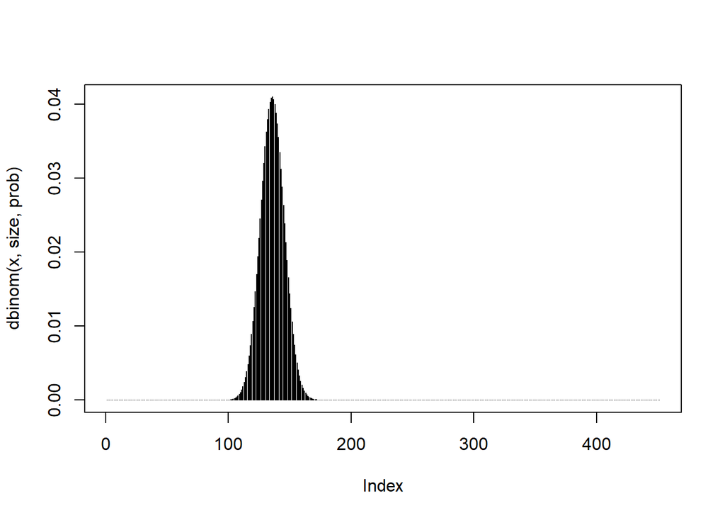

```r
x = seq(0,450,1)
prob = .3
size = 450
pmf = dbinom(x,size,prob)
plot(dbinom(x,size,prob),type="h")
```

## Problem 5

Find formula for Var(X+Y+Z).

Consider the formula Var(X+Y) = Var(X) + Var(Y) + 2Cov(x,y) Similarly we can write the formula: Var(X+Y+Z) = Var(x) + Var(y) + Var(Z) + $\Sigma Cov(X_i,X_j)$ = Var(x) + Var(y) + Var(Z) + Cov(X,Y) + Cov(X,Z) + Cov(Y,Z)

## Problem 6

Let X be the normal random variable X~N($\mu,\sigma$). Calculate its expected value in two ways, using the definition of expected value and the moment generating function of X.

$E[X] = \int_{-\infty}^{\infty}(x-\mu)e^{-(x-\mu)^2/2\sigma}dx = \int_{-\infty}^{\infty}ye^{-y^2/2}dy = -e^{-y^2/2}|_{-\infty}^{\infty} = 0$ $E[e^t\Sigma_{i=1}^nX_i] = \Pi_{i=1}^{n}E[e^{tX_i}] = e^{\mu t+\sigma t/2}$